# 第3章 一般化線形モデル（GLM）

obata.yoshimasa

2021/9/26

## 一般化線形モデル

「ばらつきは何でもかんでも正規分布」と考えるのはおかしいだろう —— というのが一般化線形モデル

ex) 目的変数がポアソン分布に従うと仮定したポアソン回帰

## 3.1 例題：個体ごとに平均種子数が異なる場合

標本：架空植物100個体

- 種子数 $y_i$ (目的変数)
- 属性（誤差（個体差）を与える観測データ）
  - 体サイズ $x_i$
  - 施肥処理の有無 $f_i$ (f : Factor)
    - 処理C：全個体中50個体 $(i \in {1, 2, \cdots, 50})$ は何も処理をしていない群
    - 処理T：残りの50個体 $(i \in {51, 52, \cdots, 100})$ は処理（肥料）を加えた群

→ $x_i$ と $f_i$ が種子数 $y_i$ にどう影響しているのか知りたい.

## 3.2 観測されたデータの概要を調べる

### データ読み込み

CSVファイルを読み込んでデータフレームとして変数dに格納

```r
# f列をfactorとするため, 引数に"stringsAsFactors = TRUE"を追加
d <- read.csv("../data/data3a.csv", stringsAsFactors = TRUE)
# print(d)
head(d, 5)
```

```
##    y     x f
## 1  6  8.31 C
## 2  6  9.44 C
## 3  6  9.50 C
## 4 12  9.07 C
## 5 10 10.16 C
```

デフォルトがFALSEになっているため注意

-> https://www.rdocumentation.org/packages/utils/versions/3.6.2/topics/read.table

```r
getOption("stringsAsFactors")
```

```
## [1] FALSE
```

### 概要の確認

#### 列ごとの確認

```r
# x列・y列のみの表示
d$x
```

```
##   [1]  8.31  9.44  9.50  9.07 10.16  8.32 10.61 10.06  9.93 10.43 10.36 10.15
##  [13] 10.92  8.85  9.42 11.11  8.02 11.93  8.55  7.19  9.83 10.79  8.89 10.09
##  [25] 11.63 10.21  9.45 10.44  9.44 10.48  9.43 10.32 10.33  8.50  9.41  8.96
##  [37]  9.67 10.26 10.36 11.80 10.94 10.25  8.74 10.46  9.37  9.74  8.95  8.74
##  [49] 11.32  9.25 10.14  9.05  9.89  8.76 12.04  9.91  9.84 11.87 10.16  9.34
##  [61] 10.17 10.99  9.19 10.67 10.96 10.55  9.69 10.91  9.60 12.37 10.54 11.30
##  [73] 12.40 10.18  9.53 10.24 11.76  9.52 10.40  9.96 10.30 11.54  9.42 11.28
##  [85]  9.73 10.78 10.21 10.51 10.73  8.85 11.20  9.86 11.54 10.03 11.88  9.15
##  [97]  8.52 10.24 10.86  9.97
```

```r
d$y
```

```
##   [1]  6  6  6 12 10  4  9  9  9 11  6 10  6 10 11  8  3  8  5  5  4 11  5 10  6
##  [26]  6  7  9  3 10  2  9 10  5 11 10  4  8  9 12  8  9  8  6  6 10 10  9 12  6
##  [51] 14  6  7  9  6  7  9 13  9 13  7  8 10  7 12  6 15  3  4  6 10  8  8  7  5
##  [76]  6  8  9  9  6  7 10  6 11 11 11  5  6  4  5  6  5  8  5  9  8  6  8  7  9
```

```r
# f列(因子：factor)のみの表示
# CSVファイルを読み込んだ時、文字列を含む列はfactorに変換される.
d$f
```

```
##   [1] C C C C C C C C C C C C C C C C C C C C C C C C C C C C C C C C C C C C C
##  [38] C C C C C C C C C C C C C T T T T T T T T T T T T T T T T T T T T T T T T
##  [75] T T T T T T T T T T T T T T T T T T T T T T T T T T
## Levels: C T
```

#### class()を用いてデータオブジェクトが属するクラスを表示

```r
class(d)
```

```
## [1] "data.frame"
```

```r
# yは整数のみのため"integer"
class(d$y)
```

```
## [1] "integer"
```

```r
# xは実数も含むため"numeric"
class(d$x)
```

```
## [1] "numeric"
```

```r
# fは文字列を含むため"factor"
class(d$f)
```

```
## [1] "factor"
```

#### 基本統計量

```r
summary(d)
```

```
##        y               x          f
##  Min.   : 2.00   Min.   : 7.190   C:50
##  1st Qu.: 6.00   1st Qu.: 9.428   T:50
##  Median : 8.00   Median :10.155
##  Mean   : 7.83   Mean   :10.089
##  3rd Qu.:10.00   3rd Qu.:10.685
##  Max.   :15.00   Max.   :12.400
```

## 3.3 統計モデリングの前にデータを図示する

### 散布図

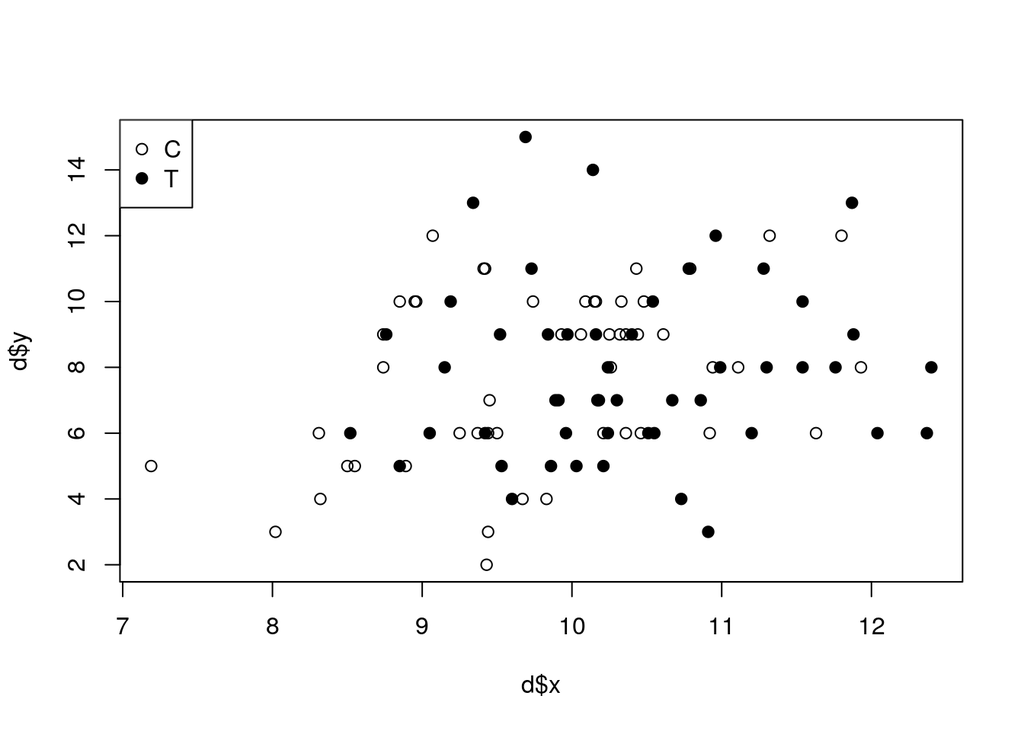

```r
plot(d$x, d$y, pch = c(21, 19)[d$f])
legend("topleft", legend = c("C", "T"), pch = c(21, 19))
```

### 箱ひげ図

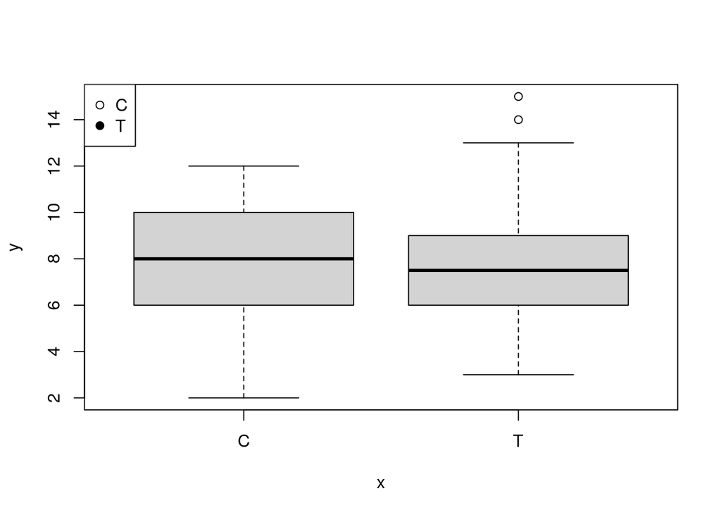

```r
plot(d$f, d$y)
legend("topleft", legend = c("C", "T"), pch = c(21, 19))
```

## 3.4.1 線形予測子と対数リンク関数

ポアソン回帰の説明はこちらが詳しい -> https://www.slideshare.net/logics-of-blue/2-3glm

#### ポアソン分布

第2章同様、ある個体 $i$ の種子数が $y_i$ である確率 $p(y_i|\lambda_i)$ は, ポアソン分布に従うと仮定する.

$$p(y_i | \lambda_i) = \frac{\lambda_i^{y_i} exp(-\lambda_i)}{y_i !}$$

#### 線形予測子とリンク関数

個体ごとに異なる平均種子数 $\lambda_i$ を説明変数 $x_i$ の関数として定義する.

ポアソン分布は$\lambda$によって決まるため、$\lambda$を推定する予測式を立てる必要がある.

$$\lambda_i = exp(\beta_1 + \beta_2 x_i) \\
\Leftrightarrow \ log \lambda_i = \beta_1 + \beta_2 x_i \ \ \cdots ①$$

①式の左辺と右辺はそれぞれ次のように呼ぶ.

- 左辺：(対数)リンク関数
- 右辺：線形予測子

ポアソン回帰のGLMで対数リンク関数が用いられる理由 - $\lambda = exp(線形予測子) \ge 0$ であり, 常に非負になる

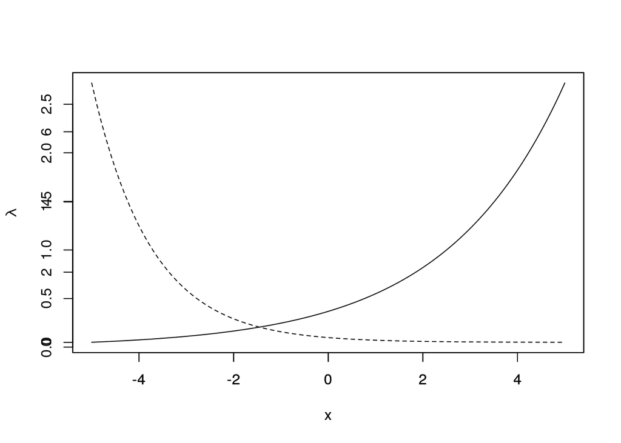

```r
lambda_a <- function(x) {
  β_1 <- -1
  β_2 <- 0.4
  return(exp(β_1 + β_2*x))
}

lambda_b <- function(x) {
  β_1 <- -2
  β_2 <- -0.8
  return(exp(β_1 + β_2*x))
}

plot(lambda_a, -5, 5, ylab="λ")
par(new=T)
plot(lambda_b, -5, 5, ylab="", lty=2)
```

## 3.4.2 あてはめとあてはまりの良さ

ポアソン回帰は、対数尤度$logL$ が最大になるパラメータ $\hat{\beta_1}, \hat{\beta_2}$ を決めること.

$$\log L(\beta_1, \beta_2) = \sum_{i} \log \frac{\lambda_i^{y_i} exp(-\lambda_i)}{y_i !}$$

Rでは次のように実行

```r
fit <- glm(y ~ x, data = d, family = poisson(link = "log"))
fit
```

```
##
## Call:  glm(formula = y ~ x, family = poisson(link = "log"), data = d)
##
## Coefficients:
## (Intercept)            x
##     1.29172      0.07566
##
## Degrees of Freedom: 99 Total (i.e. Null);  98 Residual
## Null Deviance:       89.51
## Residual Deviance: 84.99     AIC: 474.8
```

```r
summary(fit)
```

```
##
## Call:
## glm(formula = y ~ x, family = poisson(link = "log"), data = d)
##
## Deviance Residuals:
##     Min       1Q   Median       3Q      Max
## -2.3679  -0.7348  -0.1775   0.6987   2.3760
##
## Coefficients:
##             Estimate Std. Error z value Pr(>|z|)
## (Intercept)  1.29172    0.36369   3.552 0.000383 ***
## x            0.07566    0.03560   2.125 0.033580 *
## ---
## Signif. codes:  0 '***' 0.001 '**' 0.01 '*' 0.05 '.' 0.1 ' ' 1
##
## (Dispersion parameter for poisson family taken to be 1)
##
##     Null deviance: 89.507  on 99  degrees of freedom
## Residual deviance: 84.993  on 98  degrees of freedom
## AIC: 474.77
##
## Number of Fisher Scoring iterations: 4
```

1. Estimate : 最尤推定値
2. Std.Error : Estimateのばらつきが正規分布であると仮定したときの標準誤差
3. z value : Estimate / Std.Error. Wald信頼区間を構成でき, Wald統計量とも呼ばれる.
4. Pr(>|z|) : (今回のポアソン回帰の場合) P値にみたてて検定することが可能 ※詳細は書籍参照

ただし, モデル評価は第４章のモデル選択を使用した方が良い.

最大対数尤度は次のように表示

```r
logLik(fit)
```

```
## 'log Lik.' -235.3863 (df=2)
```

## 3.4.3 ポアソン回帰による予測

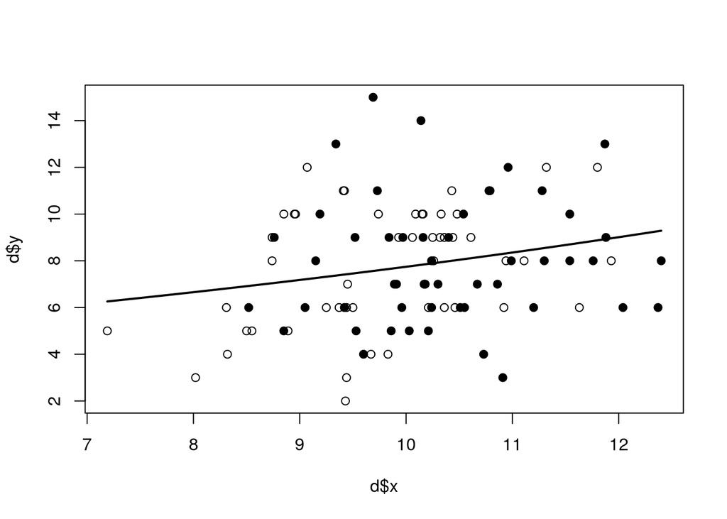

```r
xx <- seq(min(d$x), max(d$x), length = 100)
plot(d$x, d$y, pch = c(21, 19)[d$f])
lines(xx, exp(1.29 + 0.0757 * xx), lwd=2)
```

## 3.5 説明変数が因子型の統計モデル

次のようにダミー変数化してモデルに組み込む.

$$\lambda_i = exp(\beta_1 + \beta_3 d_i) \\
d_i = \left\{
\begin{array}{ll}
0 & (f_i = C) \\
1 & (f_i = T)
\end{array}
\right.$$

```r
fit_f <- glm(y ~ f, data = d, family = poisson)
fit_f
```

```
##
## Call:  glm(formula = y ~ f, family = poisson, data = d)
##
## Coefficients:
## (Intercept)           fT
##     2.05156      0.01277
##
## Degrees of Freedom: 99 Total (i.e. Null);  98 Residual
## Null Deviance:       89.51
## Residual Deviance: 89.48     AIC: 479.3
```

```r
summary(fit_f)
```

```
##
## Call:
## glm(formula = y ~ f, family = poisson, data = d)
##
## Deviance Residuals:
##      Min        1Q    Median        3Q       Max
## -2.47515  -0.69941   0.04264   0.72467   2.25204
##
## Coefficients:
##             Estimate Std. Error z value Pr(>|z|)
## (Intercept)  2.05156    0.05070  40.463   <2e-16 ***
## fT           0.01277    0.07148   0.179    0.858
## ---
## Signif. codes:  0 '***' 0.001 '**' 0.01 '*' 0.05 '.' 0.1 ' ' 1
##
## (Dispersion parameter for poisson family taken to be 1)
##
##     Null deviance: 89.507  on 99  degrees of freedom
## Residual deviance: 89.475  on 98  degrees of freedom
## AIC: 479.25
##
## Number of Fisher Scoring iterations: 4
```

```r
logLik(fit_f)
```

```
## 'log Lik.' -237.6273 (df=2)
```

## 3.6 説明変数が数量型＋因子型

次のような重回帰式で考える.

$$\log \lambda_i = \beta_1 + \beta_2 x_i + \beta_3d_i$$

Rを実行すると施肥処理の効果（fT）のEstimateが正であったのに、  
このモデルではマイナスと推定される.

```r
fit_all <- glm(y ~ x + f, data = d, family = poisson)
fit_all
```

```
##
## Call:  glm(formula = y ~ x + f, family = poisson, data = d)
##
## Coefficients:
## (Intercept)            x           fT
##     1.26311      0.08007     -0.03200
##
## Degrees of Freedom: 99 Total (i.e. Null);  97 Residual
## Null Deviance:       89.51
## Residual Deviance: 84.81     AIC: 476.6
```

```r
summary(fit_all)
```

```
##
## Call:
## glm(formula = y ~ x + f, family = poisson, data = d)
##
## Deviance Residuals:
##     Min       1Q   Median       3Q      Max
## -2.3977  -0.7337  -0.2023   0.6795   2.4317
##
## Coefficients:
##             Estimate Std. Error z value Pr(>|z|)
## (Intercept)  1.26311    0.36963   3.417 0.000633 ***
## x            0.08007    0.03704   2.162 0.030620 *
## fT          -0.03200    0.07438  -0.430 0.667035
## ---
## Signif. codes:  0 '***' 0.001 '**' 0.01 '*' 0.05 '.' 0.1 ' ' 1
##
## (Dispersion parameter for poisson family taken to be 1)
##
##     Null deviance: 89.507  on 99  degrees of freedom
## Residual deviance: 84.808  on 97  degrees of freedom
## AIC: 476.59
##
## Number of Fisher Scoring iterations: 4
```

```r
logLik(fit_all)
```

```
## 'log Lik.' -235.2937 (df=3)
```

## 3.6.1 対数リンク関数のわかりやすさ：かけ算される効果

対数リンク関数は足し算のように見えて掛け算で表される.

$$\lambda_i = exp(\beta_1 + \beta_2 x_i + \beta_3d_i) \\
= exp(\beta_1) × exp(\beta_2 x_i) × exp(\beta_3 d_i)$$

詳細は書籍参照.

## 3.7 「何でも正規分布」「何でも直線」には無理がある

線形回帰(LM)を仮定した場合の指摘点

- 正規分布は連続的な値を扱う確率分布だったはずでは？
- カウントデータなのに平均値の予測がマイナスになる理由は？
- 図でみると「ばらつき一定」ではなさそうなのに、分散一定を仮定？

ポアソン分布のGLMで説明しようとした場合の利点

- ポアソン分布を使っているのでカウントデータに正しく対応
- 対数リンク関数を使えば平均値はつねに非負
- $y$ のばらつきは平均とともに増大する

以上